# 00_visual

[figure not shown]

Profesora Carolina Luque

**Resultado de aprendizaje:** Analiza datos de diversa índole mediante técnicas de estadística descriptiva y probabilidad.

**Hito 1:** Análisis exploratorio de datos.

**Temas:**

- Principios esenciales para la visualización de gráficos estadísticos.
- Gráficos estadísticos populares.

# **Principios escenciales para la visualización de gráficos estadísticos**

## **Título claro y descriptivo**

El gráfico debe llevar un título que describa con claridad la información presentada. Por ejemplo, Distribución de las ventas por región en 2023 es más adecuado que simplemente Ventas. Asimismo, es importante escribir en el idioma en el que se redacta el informe, evitando mezclas entre español e inglés. Verificar que el tipo y tamaño de fuente sean adecuados.

## **Etiquetas de ejes claras y precisas**

Los ejes deben estar claramente etiquetados con unidades, cuando corresponda. Por ejemplo, *Ventas (miles de dólares)*. Además, deben incluir nombres precisos que identifiquen la variable representada. Es fundamental evitar abreviaciones ambiguas o el uso de unidades no especificadas.

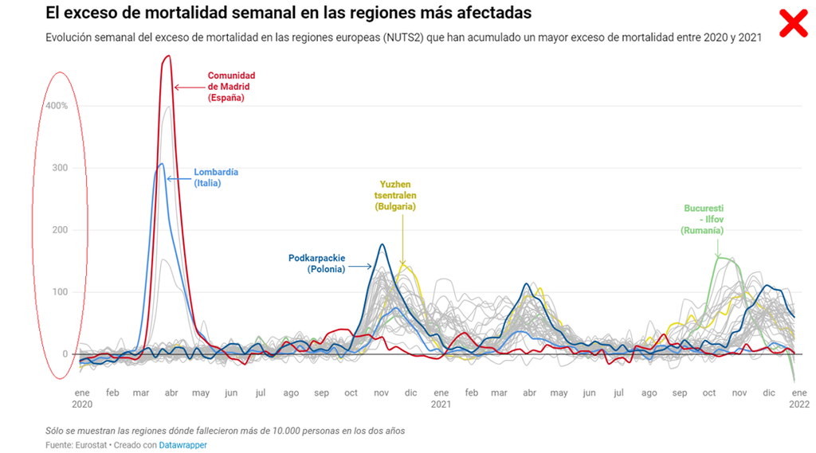

## **Leyendas adecuadas**

Si el gráfico presenta agrupaciones del conjuntos de datos, como diferentes categorías o subgrupos, es fundamental incluir una leyenda que aclare el significado de cada color, forma o patrón. La leyenda debe colocarse en una posición visible, sin obstruir la visualización del gráfico. Por ejemplo, ubicarla en la esquina superior derecha o debajo del gráfico.

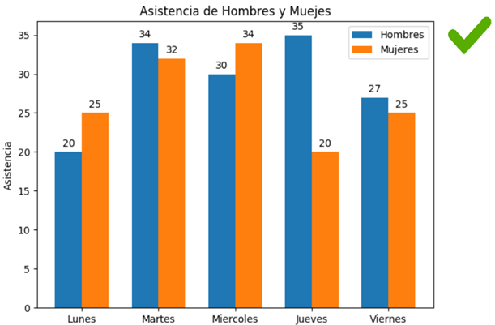

## **Uso de colores o patrones distintivos**

Utilizar colores o patrones claramente diferenciables para facilitar la distinción entre categorías o grupos. Evita emplear colores demasiado similares que puedan dificultar la identificación de las diferentes secciones. Evitar sobrecarga de colores.

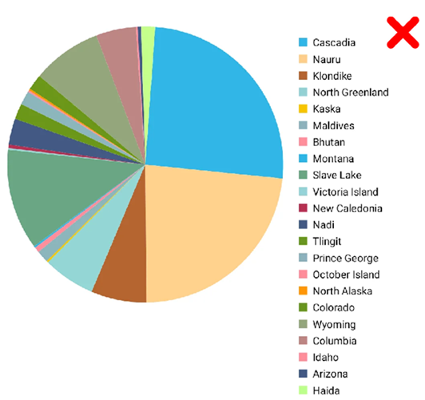

## **Proporcionalidad y escalas correctas**

Los gráficos deben mantener la proporcionalidad correcta para evitar malinterpretaciones. Esto significa que las escalas de los ejes deben comenzar en cero o utilizar una ruptura clara si es necesario. Evitar truncar los ejes para exagerar las diferencias.

[figure not shown]

## **Evitar el exceso de información**

Los gráficos deben presentar la cantidad justa de información para evitar la sobrecarga visual. Si un gráfico contiene demasiados datos, considera dividir la información en varios gráficos más simples. Por ejemplo, en lugar de usar un gráfico de líneas con 10 series de datos, es mejor separarlos en dos gráficos si el número de líneas resulta confuso.

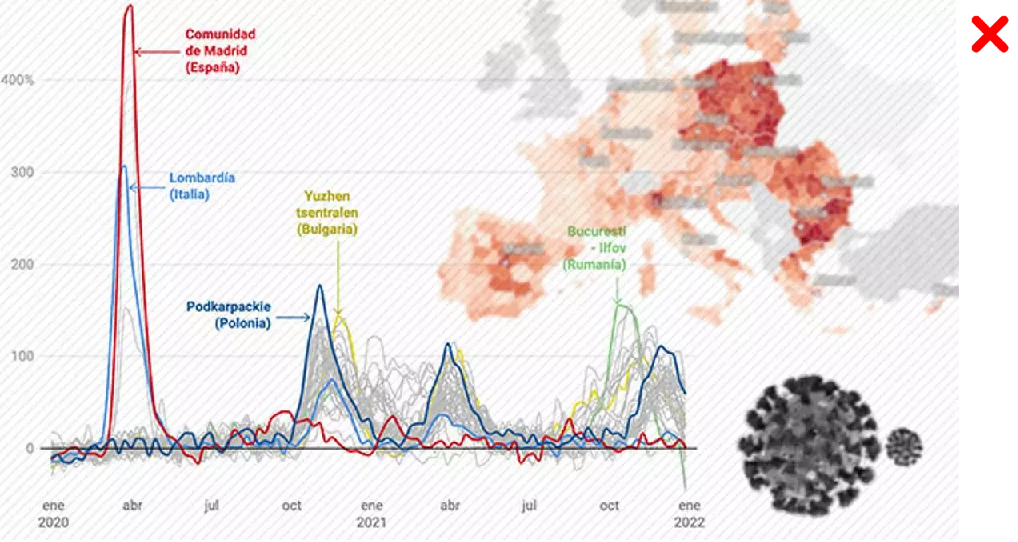

## **Datos de referencia (ejes y líneas guías)**

Utiliza ejes y líneas guías (en un color tenue o de fondo) para facilitar la interpretación de las posiciones y valores de los datos, sin que estas guías distraigan o dominen el gráfico. Asegúrate de que las líneas guías sean lo suficientemente sutiles para no desviar la atención del contenido principal.

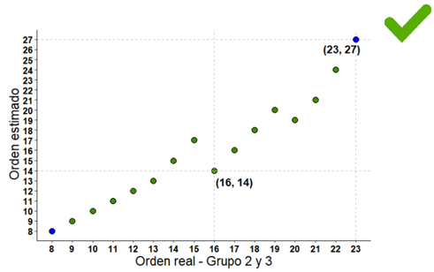

## **Incluir anotaciones cuando sea necesario**

Incluir anotaciones o descripciones para resaltar datos importantes o excepcionales que necesiten destacarse. Las anotaciones deben ser concisas y no excesivas, pero útiles para aclarar puntos críticos del análisis. Por ejemplo, en un gráfico de ventas mensuales, podrías añadir una nota como *El color más oscuro indica el mayor aumento en ventas observado en julio.*

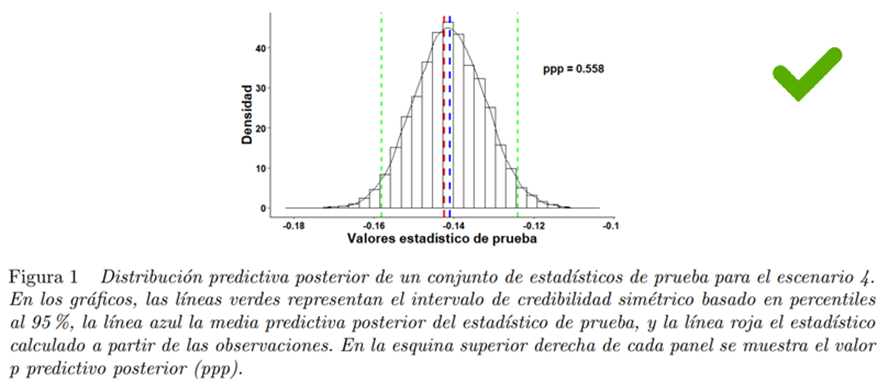

## **Mantener el gráfico simple y directo**

Evitar adornos innecesarios, como sombras, texturas o representaciones en 3D, que no aportan valor y pueden distraer. En muchos casos, los gráficos en 2D son más claros y efectivos que aquellos con efectos tridimensionales.

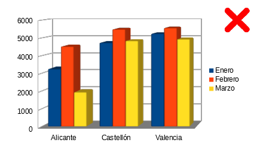

## **Consideraciones sobre el público**

Conocer la audiencia para garantizar que los gráficos sean comprensibles para el público objetivo. Ajustar la complejidad y el nivel técnico según sea necesario. Por ejemplo, para audiencias no técnicas, simplifica los gráficos y proporciona más contexto. En cambio, para audiencias expertas, puedes usar gráficos más detallados y omitir explicaciones extensas.

## **Fuente de los datos**

Siempre incluir la fuente de los datos utilizados en el gráfico, sobre todo en presentaciones formales o publicaciones científicas.

# **Gráficos estadísticos polulares**

- **Gráfico de barras**: Permite comparar cantidades entre diferentes categorías. Las barras pueden ser verticales u horizontales.
- **Histograma**: Muestra la distribución de una variable continua dividiendo los datos en intervalos.
- **Gráfico de líneas**: Utilizado para representar tendencias a lo largo del tiempo o la evolución de una variable continua.
- **Gráfico de dispersión**: Visualiza la relación entre dos variables continuas, siendo útil para identificar correlaciones o patrones.
- **Diagrama de caja**: Representa la distribución de datos a través de cuartiles, destacando valores atípicos (outliers).
- **Gráfico circular**: Representa proporciones relativas entre diferentes categorías y es útil para resaltar la relación de las partes con el todo.
- **Gráfico de áreas**: Similar al gráfico de líneas, pero muestra el área bajo la curva, lo que facilita la comparación de acumulaciones de datos a lo largo del tiempo.
- **Mapa de calor**: Visualiza patrones, correlaciones o variaciones en un conjunto de datos mediante una escala de colores.
- **Gráfico de burbujas**: Similar al gráfico de dispersión, pero introduce un tercer valor representado por el tamaño de las burbujas, permitiendo visualizar tres dimensiones de datos.
- **Diagrama de Pareto**: Ayuda a identificar los factores más significativos en un conjunto de datos mediante una combinación de barras y una línea acumulativa.
- **Diagrama de violín**: Muestra la distribución de datos a través de la densidad de probabilidad, combinando características de un box plot.
- **Gráfico de radar o araña**: Compara múltiples variables de forma radial, ideal para evaluar el rendimiento de varias categorías simultáneamente.
- **Diagrama de dispersión 3D**: Explora relaciones entre tres variables continuas, representando puntos en un espacio tridimensional.
- **Diagrama de flujo**: Visualiza flujos o movimientos entre diferentes categorías o procesos, facilitando la comprensión de secuencias y conexiones.

Por favor consultar [uso adecuado de gráficos](https://drive.google.com/file/d/1XRcgGU2hX4HU296A6JUPuX4DagGPT7hp/view?usp=drive_link)

# **Práctica 1. Representación gráfica de conjunto de datos**

Dirijase al aula virtual

1. Decargue el archivo **03_prac1-visual.ipynb**
2. Guarde los archivos en su lugar de trabajo

# **Referencias**

- Rajagopalan, G. (2021). A Python Data Analyst's Toolkit: Learn Python and Python-based Libraries with Applications in Data Analysis and Statistics. Springer.
- Igual, L. and Seguí, S. (2017). Introduction to Data Science A Python Approach to Concepts, Techniques and Applications. Springer.
- Haslwanter, T. (2016). An Introduction to Statistics with Python With Applications in the Life Sciences. Springer.